# Week06_Wednesday slides

## Week 06 Wednesday

March 4, 2026

## Announcements

1. A draft list of included articles **(initial list due *tonight*)**
2. A06 due **Friday, 3/6/2026**

## Goals

1. Quick discussion of assignment deliverable expectations, esp: regarding naming/format
2. Check-in on A06
3. Euler Angles (30 min)
4. Work time for Class exercises: Odometry and MAPPING!

# Complex Rotations with Euler Angles

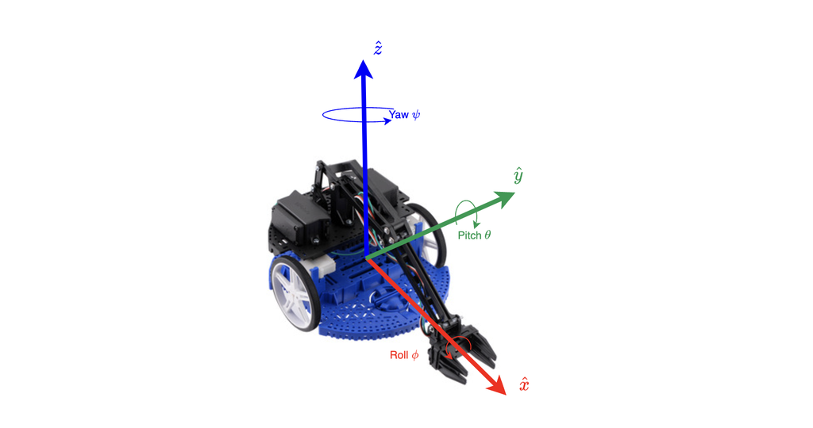

## *order matters* when using Euler angles

\begin{equation} \vec{p}^\prime = R_{zyx}(\phi,\theta,\psi)\vec{p} = R_x(\phi)\cdot R_y(\theta) \cdot R_z(\psi) \cdot\vec{p} \end{equation}

[interactive chart not shown]

## Constructing the three individual rotation matrices for Euler Angles

Given the drawings in Figure 8 below, we can easily construct the 3D rotation matrices for the individual Euler angle rotations $_A^BR$ about the yaw (z), pitch (y), and roll (x) axes.

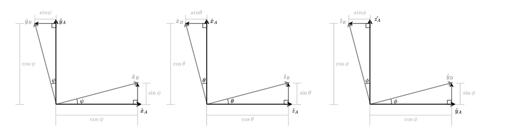

**Figure 8: The three individual rotations comprising a 3D Euler angle transformation**

## The Three Rotation Matrices for Yaw, Pitch, Roll

\begin{equation} _A^B R_z (\psi) = \begin{bmatrix} \cos \psi & \sin \psi & 0 \\ -\sin\psi & \cos \psi & 0 \\ 0 & 0 & 1 \end{bmatrix} \end{equation}

\begin{equation} _A^B R_y (\theta) = \begin{bmatrix} \cos\theta & 0 &-\sin\theta \\ 0 & 1 & 0 \\ \sin \theta & 0 & \cos \theta \end{bmatrix} \end{equation}

\begin{equation} _A^B R_x (\phi) = \begin{bmatrix} 1 & 0 & 0 \\ 0 & \cos \phi & \sin \phi \\ 0 & -\sin \phi & \cos \phi \\ \end{bmatrix} \end{equation}

As always, if you actually need $_B^A R$ rather than $_A^B R$, you can simply use $ _B^A R = _A^BR^T$. In any case, computing the "total" 3D Euler angle transformation using the $ZYX$ convention is as simple as computing:

\begin{equation} _A^B R_{zyx}(\psi,\theta,\phi) = _A^BR_x(\phi)\cdot _A^BR_y(\theta) \cdot _A^B R_z(\psi) \end{equation}

Once this transformation (or its transpose/inverse as appropriate) is constructed, it can easily be used in a 3D Homogeneous transformation. This is incredibly powerful, since it allows us to transform *any* vector measured in *any* frame into *any other frame* in 3 dimensions.

## Limitations of Euler Angles

Euler angles are one of the most common ways to describe a frame's 3D orientation in space, but they do have limitations. "Gimal lock," or ambiguity resulting from multiple sets of Euler angles describing the same orientation (leaving one of the angles essentially undefined), is a real problem for certain applications. While Euler angles are great for robots whose orientation is relatively constrained to planar motion (think about a car, which only moves a small amount in the pitch and roll directions relative to yaw), they pose challenges for certain applications. This has led to other ways to describe 3D orientations that are able to escape this ambiguity.

## Exercise

Modify the Romi controller in the Week05_InClass world. Add a function that computes a new estimate of odometry based on old estimates, along with current wheel velocities. Your function should have the form

```
def doOdometry(Xold,Yold,Yawold,Vl,Vr,timestep):
    #your function should:
    #1. Compute yaw rate based on Vl, Vr, and romi geometry
    #2. Use Euler integration to find Yawnew based on Yawold, yaw rate and timestep
    #3. Compute body-fixed velocity bv based on Vl, Vr, and romi geometry
    #4. Rotate body-fixed velocity to find VX, VY in global frame
    #5. Use Euler integration to find Xnew, Ynew based on Xold, Yold, VX, Vy, timestep

    return Xnew, Ynew, Yawnew #can return more (i.e. yaw rate) if you like
```

Remember, Euler integration allows us to compute a "new" value for some integral $y(k)$ based on an "old" value $y(k-1)$, a velocity $\dot{y}(k-1)$, and a timestep $\Delta t$ by:

\begin{equation} y(k) = y(k-1) + \dot{y}(k-1)\Delta t \end{equation}

Which can be written without using indices and without storing our estimates in a "vector" by simply writing:

\begin{equation} y_{new} = y_{old} + \dot{y}_{old}\Delta t \end{equation}

.

.

.

.

## Exercise 2: MAPPING

Modify the Romi controller in the Week05_InClass world. Add a function that computes an estimate of the **global position** of any objects in the world that the Romi "sees" with its distance sensor.

- Use [lookup table](https://github.com/Alexanderallenbrown/ES302_Webots/blob/437461d4fe4ebda39ed2a5eb5bfd7e30ac2cedbd/protos/romi.proto#L108C21-L137C22) in Romi.proto to convert measured distance to meters from Romi's built-in distance sensor
  - Store table as numpy array
  - Interpolate using numpy.interp()
  - https://numpy.org/doc/stable/reference/generated/numpy.interp.html
- Using Romi's odometry and measured distance, store allocentric coordinates of any detected object in a text file.
  - careful with this measurement. It's from the claw edge, not from Romi center. Does this matter? Think about it, and compensate if necessary (add offset, which you can measure for now)
- Do not store values that are too close or too far to trust.
- Plot "map" by plotting XY coordinates of detected objects. Compare to shape of Romi arena.

.

.

.

.

## Romi Prox Sensor Lookup Table

Columns are: $\begin{bmatrix} dist(m) & dist(counts) & variance (m^2)\end{bmatrix}$

```
lookupTable = np.array([[0.0254,991,.005],[0.0508,987,.005],[0.0762,980,.005],[0.1016,853,.005],[0.127,712,.005],[0.1524,585,.005],[0.1778,502,.005],[0.2032,435,.005],[0.2286,383,.005],[0.254,346,.005],[0.2794,316,.005],[0.3048,296,.005],[0.3302,281,.005],[0.3556,268,.005],[0.381,255,.005],[0.4064,248,.005],[0.4318,239,.005],[0.4572,233,.005],[0.4826,229,.005],[0.508,223,.005],[0.5334,219,.005],[0.5588,215,.005],[0.5842,211,.005],[0.6096,209,.005],[0.635,207,.005],[0.6604,205,.005],[0.6858,203,.005],[0.7112,201,.005],[0.7366,200,.005]])
```